# Week 4 Project Assignment

Derrick Attfield

2017/03/09

## Data Management

### 1. Dates

Describing the date and time on which the measurements were sourced the date data is represented in 3 separate columns:

a. Date in character atomic class,

b. Datepart1 in integer atomic class,

c. Datepart2 in integer atomic class.

### 3. Descriptive data

a. Username -> in character atomic class, containing the names of the participants.

b. X -> in integer atomic class which as far as can be established is a sequential identify number for the observation.

c. New Window -> in character atomic class containing yes and no; the meaning of this variable could not be established.

d. Window number -> in integer atomic class, the meaning of this variable could not be established.

### 5. Measures

A large number of measurements were recorded during the data collection period. I elected to separate the data set into 4 subsets based on (a) the device (named deviceData), (b) the site from where the measure was recorded (named sitesData), (c) the type of metric that was recorded (named metricsData) and finally (d) the statistics (this data set was not used). All variables related to totals and “amplitude” excluded. Next I explored the data through various plots to develop an overall intuition for the data. Furthermore, I was able to identify what appeared to be a correlation between the date and time on which the measures were recorded and the class for which it was labelled (fig. 1).

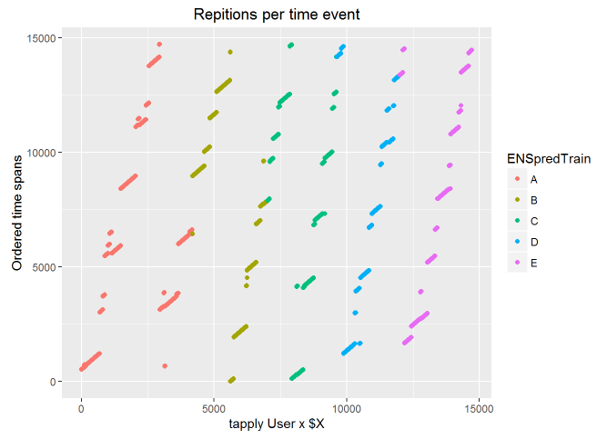

Fig.1

## Analysis and prediction

The goal is to predict to which classe (sic) dumbbell lifts were labelled in an unseen test set.  
Based on the fact that this was clearly a classification problem I elected to use random forests to build a model for prediction.  
The raw data was partitioned into a Train set (75%) and a Validate set (25%) using the sample() function. As mentioned above the raw data (for both the Train and Validaet partitions were divided into 3 subsets deviceData set, sitesData set and metricsData set.  
The variables included in the deviceData and sitesData is the same data subset. A separate random forest using the randomForest() function was built for each of the data sets. The predictions from these 3 random forests were then again combined to create a ENSData set and applied to a 4 th random forest. The code to implement the 4 random forests is shown below in code sample 1.

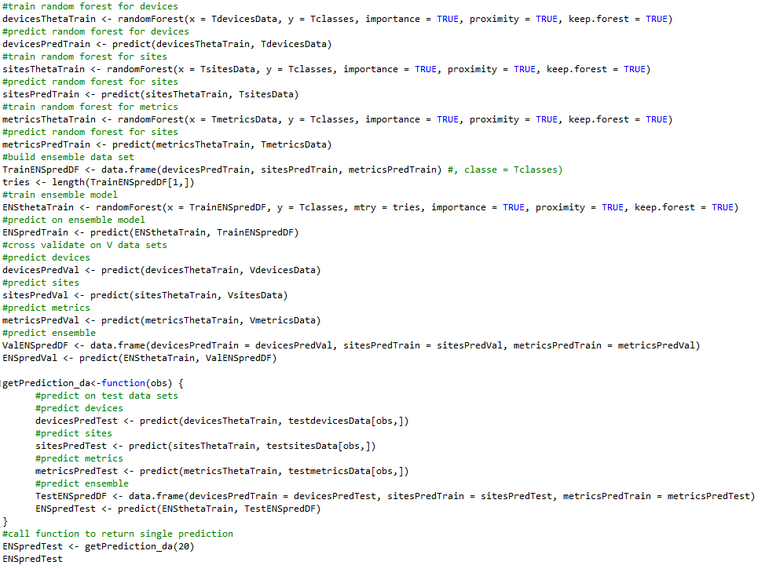

Code sample 1.

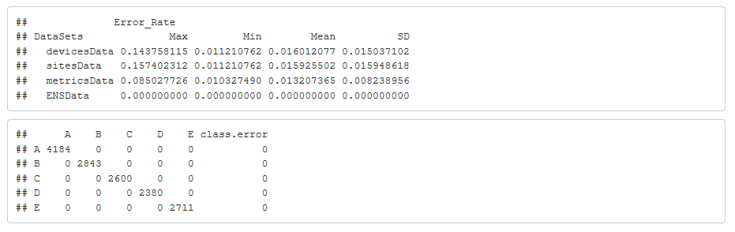

Table 1

The overall predictive accuracy was better than 98% from the ensemble random forest. I did not use the tuneRF() function because of the observed 0 mean OOB error rate but would have, should the OOB error not have been satisfactory. Furthermore, the deviceData and sitesData set contained the same observations in the 1st build of the complete model which yielded the 0 OOB error rate. If the OOB error rate was not acceptable the deviceData set would have been recreated combining all measures of each device and the sitesData set would have been recreated combining all the measures of each site through a covariate generation algorithm.

## Variable importance

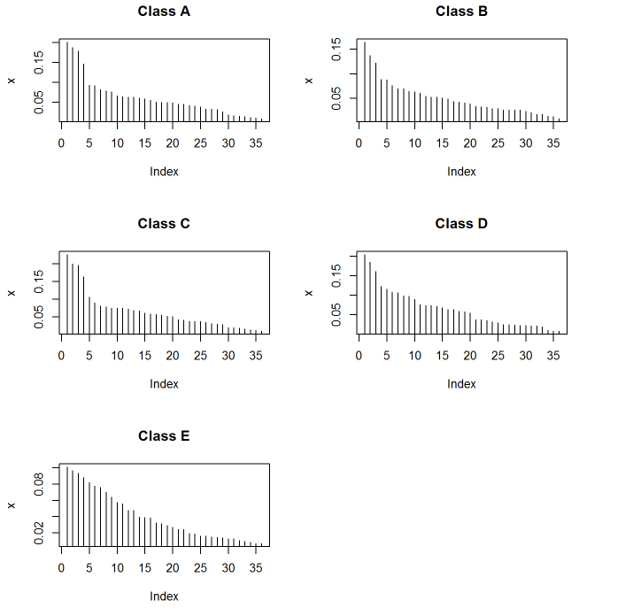

Fig. 2

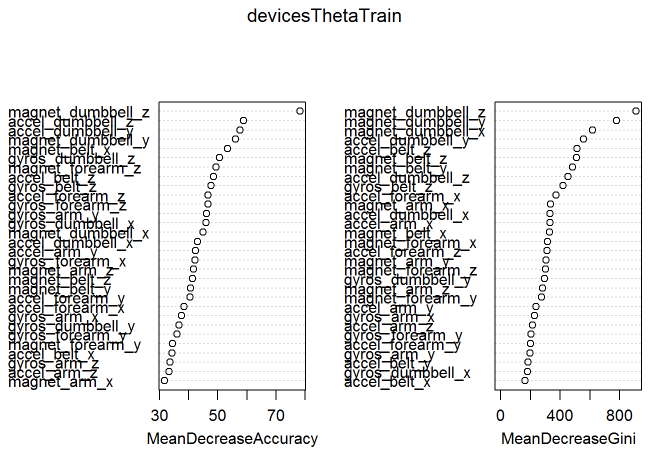

Fig. 3

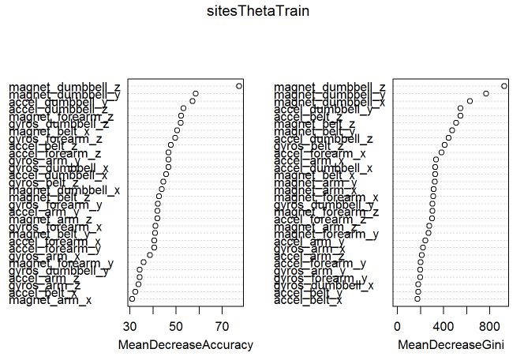

Fig. 4

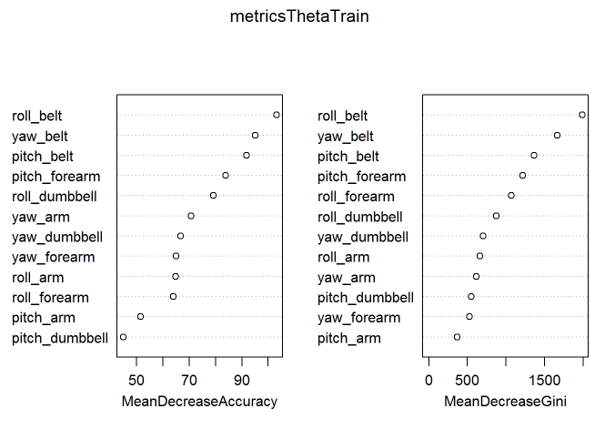

Fig. 5

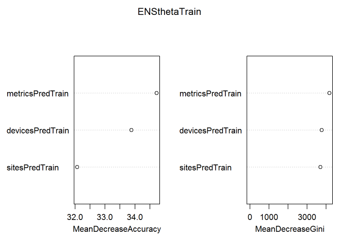

Fig. 6

## Test set prediction

The test set data was loaded and pre-processed in the same manner as described for the training data set. A separate function to execute the prediction on the 4 predictors was written and sourced to R, which allowed an interactive call of a function with the number of the test set observation that was required to be predicted, this made the completion of the assignment quiz simple. The solution predicted 20 of 20 test examples correctly on submission of the quiz. The submission grid is intentionally not displayed.